# Besta Tilboðið

The Stormlands

Nemendur: Benedikt Arnar Davíðsson, Halldór Óli Gunnarsson, Valur Ingi Sigurðarson

# Samantekt

Markmið verkefnisins var að greina verðlagningu og aðgengi bjóra í miðbæ Reykjavíkur og bera saman við verð í Vínbúðinni. Einnig voru borin saman lukkuhjól í miðbænum. Gögnum var aflað annars vegar öllum börum í bænum og af vefsíðunni [vinbudin.is](https://www.vinbudin.is/heim) með aðstoð REGEX til að vinna úr HTML-gögnum. Gagnasöfnun náði til 36 staða í bænum þar sem skráðar voru upplýsingar um bjórtegundir, verð, stærð glasa, Happy Hour tilboð og lukkuhjól. Gögn voru síðan unnin í SQL og sett fram í Power BI mælaborði til sjónrænnar framsetningar. Helstu niðurstöður sýna að verð á bjór er að meðaltali 3,5 sinnum hærra í miðbænum en í Vínbúðinni, og ódýrasti drykkurinn var á SKOR (Gull Lite, 400ml, 1300kr.). Lukkuhjól staðanna höfðu mismiklar líkur á vinningi, þar sem Dubliner skar upp úr með hæsta hlutfallið.

Verkefnið nýtti hæfni í gagnasöfnun, úrvinnslu og greiningu með áherslu á notkun REGEX og SQL til að tryggja nákvæmni og samræmi. Þetta leiddi til heildstæðra niðurstaðna sem nýtast í samanburði og framtíðargreiningum.

# Inngangur

„Besta Tilboðið“ er verkefni sem miðar að því að skoða verðlagningu og fjölbreytileika bjóra á dælu í miðbæ Reykjavíkur og bera saman við verð í Vínbúðinni. Bar- og skemmtistaðamenning hefur lengi verið mikilvægur hluti af menningu Háskóla Íslands, en verðlagning á drykkjum hefur mikil áhrif á upplifun viðskiptavina þessa staða. Verkefnið var sett fram með því markmiði að veita innsýn í hvernig verð breytist eftir staðsetningu og öðrum breytum eins og stærð og Happy Hour tilboðum.

Verkefnið er mikilvægt í ljósi þess að verðlagning á drykkjum hefur verið umdeilt í háskólasamfélaginu, sérstaklega þegar kemur að samanburði á verði í miðbænum og hjá Vínbúðinni. Gögnum sem safnað var fyrir þetta verkefni skapa skýran samanburð á milli staða og veita dýpri skilning á þeim þáttum sem hafa áhrif á verð. Þetta verkefni byggir á því að nýta tækni á borð við reglulegar segðir (REGEX), SQL og sjónræna framsetningu í Power BI til að tryggja að niðurstöður séu skilgreinalegar og aðgengilegar.

Bakgrunnur verkefnisins byggir á þeirri hugmynd að mælaborð og gagnagreining geta verið verkfæri til að svara lykilspurningum um verð og fjölbreytni. Í þessu verkefni er lögð áhersla á heildrænt yfirlit sem tekur til verð á bjór á dælu, Happy Hour tilboða og lukkuhjóla. Auk þess er gerður samanburður við Vínbúðina til að varpa ljósi á það hvernig verðlagning á milli þessara tveggja sviða er ólík.

Markmið verkefnisins má skipta í fjóra lykilþætti:

1. **Gagnasöfnun**: Að safna nákvæmum og eins yfirgripsmiklum gögnum og hægt er um bjór á dælu, verð, stærðir glasa, Happy Hour tilboð og lukkuhjól. Gögnin voru fengin frá 36 stöðum í miðbæ Reykjavíkur og upplýsingar um bjóranna voru fengin með reglulegum segðum (REGEX) frá vefsíðu Vínbúðarinnar.
2. **Gagnavinnsla**: Að nýta SQL fyrir úrvinnslu og hreinsun gagna og tryggja að gögnin séu samræmd og áreiðanleg.
3. **Framsetning**: Að búa til notendavænt og sjónrænt mælaborð í Power BI sem veitir innsýn í helstu niðurstöður.
4. **Samanburður og greining**: Að bera saman verðlagningu á bjór í miðbænum við verð í Vínbúðinni og kanna breytileika á öðrum þáttum eins og stærðum glasa og líkum á vinningi í lukkuhjólum.

Rannsóknarspurningar verkefnisins snúast um að svara eftirfarandi:

- Hver er meðalkostnaður bjórs á dælu í miðbæ Reykjavíkur miðað við verð í Vínbúðinni?
- Hvaða þættir hafa áhrif á verð, svo sem stærð bjórglasa og tilboð eins og Happy Hour?
- Hvaða breytileiki er til staðar í vinningslíkum lukkuhjóla á börum og hvaða staðir bjóða hagstæðustu líkurnar?

Viðfangsefnið hefur einnig tengsl við kennsluefni námskeiðsins. Gögnin voru unnin með hjálp REGEX til að sækja upplýsingar beint úr HTML-kóða vefsíðu Vínbúðarinnar. Auk þess var SQL notað til að hreinsa og skipuleggja gögnin áður en þau voru sett fram í Power BI. Með þessu var stuðst við færni í gagnasöfnun, úrvinnslu og framsetningu gagna, sem eru lykilatriði í greiningarvinnu á þessum vettvangi.

Verkefnið skiptir sköpum fyrir fjölmarga aðila, þar sem það gefur innsýn í hvernig verðlagning og tilboð breytast eftir staðsetningu og öðrum breytum. Niðurstöður verkefnisins veita upplýsingar sem geta nýst nemendum sem og almenningi til að taka upplýstar ákvarðanir. Að auki leggur verkefnið sitt af mörkum til umræðna um verðlagningu og jafnvægi á milli þess að bjóða upp á sanngjarna og hagstæða þjónustu.

Með þessu verkefni er sýnt fram á hvernig gagnaúrvinnsla og sjónræn framsetning geta haft áhrif á ákvarðanatöku. Mælaborðið sem verkefnið skilaði skapar grunn fyrir frekari greiningar og getur verið fyrirmynd að framtíðargreiningum í tengslum við neyslumynstur og verðlagningu.

# Aðferðafræði

Verkefnið „Besta Tilboðið“ var framkvæmt með skýru og skipulögðu ferli sem tryggði nákvæmni, samræmi og skilvirkni í öllu ferlinu, allt frá gagnaöflun til framsetningar niðurstaðna. Aðferðirnar voru hannaðar með það að markmiði að uppfylla rannsóknarspurningar sem voru settar fram í upphafi og svara þeim á skýran og áreiðanlegan hátt. Ferlið byggðist á þremur lykilþrepum: gagnasöfnun, gagnavinnslu og framsetningu.

## Gagnasöfnun

Gagnasöfnun var grundvallarþáttur verkefnisins þar sem öll greining og niðurstöður byggðust á gæðum og áreiðanleika gagnanna. Tvær meginleiðir voru nýttar til að safna gögnum: handvirk skráning á staðnum og sjálfvirk söfnun gagna með reglulegum segðum úr vefsíðu Vínbúðarinnar.

### Handvirk gagnasöfnun á stöðum í miðbæ Reykjavíkur

Gögnum var safnað handvirkt með heimsóknum á 36 bari og skemmtistaði í miðbæ Reykjavíkur. Sérstök áhersla var lögð á að velja fjölbreytt úrtak, allt frá hefðbundnum börum til hina ýmsu skemmtistaði og næturklúbba í Reykjavík, til að tryggja að niðurstöður endurspegluðu sem best heildarmyndina af verðlagi á bjór á dælu í miðbænum. Á hverjum stað voru eftirfarandi upplýsingar skráðar:

- Nafn staðar og staðsetning.
- Tegundir bjóra á dælu, verð þeirra og stærðir glasa.
- Upplýsingar um Happy Hour tilboð, svo sem tímasetningar og verð.
- Nánari upplýsingar um lukkuhjól, þar með talið verð, líkur á vinningi og hlutfall tapreita.

Til að tryggja samræmi í skráningu var unnið með staðlaðan spurningalista sem tók saman allar nauðsynlegar upplýsingar. Þar að auki voru teknar myndir af staðsetningum og öðrum þáttum ef nauðsyn krafðist. Þessi skipulagða aðferð gerði það mögulegt að safna saman nákvæmum og samhæfðum gögnum sem voru tilbúin til frekari úrvinnslu.

### Gagnasöfnun með reglulegum segðum (REGEX)

Gögn um verð á bjór í Vínbúðinni voru sótt með hjálp Python-forrits sem nýtti sér eiginleika reglulegra segða (REGEX). Þessi leið var valin vegna þess að hún gerði kleift að safna miklu magni gagna á sjálfvirkan og nákvæman hátt. Fyrst var útbúið textaskjal sem innihélt slóðir allra bjórtegunda á vefsíðu Vínbúðarinnar. Python-forritið las þessar slóðir og sótti viðeigandi gögn úr HTML-kóða síðunnar. Gögn sem voru einangruð með REGEX innihéldu:

- Nafn bjórtegundar.
- Verð í krónum.
- Stærð bjórs í millílítrum.

Þegar gögnin voru sótt með hjálp Python, voru þau vistuð í CSV-skrá með dálkum fyrir nafn, verð og stærð. Þessi sjálfvirka nálgun tryggði bæði áreiðanleika gagna og tímaávinning samanborið við handvirka skráningu.

## Gagnavinnsla

Markmiðið með gagnavinnslunni var að hreinsa gögnin, samræma þau og búa til vel skipulagðan gagnagrunn sem gerði kleift að framkvæma nákvæmar greiningar og útreikninga, sem og auðveldaði það að sýna niðurstöðurnar á myndrænan hátt.

### Excel - Gögn frá bænum

Eftir að gögnum hafði verið safnað, voru þau stimpluð handvirkt inn í excel og nokkrum dálkum eins og meðalverð á hverjum bar og meðal lítraverð bætt við með einföldum excel skipunum. Á sama hátt var bætt við líkur á að græða/tapa pening, enda á sléttu og líkur á að vinna eitthvað/ekkert. Að lokum var bætt við dálkum með nákvæmri staðsetningu hvers bars, sem fengin var í gegnum Google Maps ásamt dálk með slóð að mynd af hverjum bar. Þar með voru gögnin tilbúin og þau sótt sem csv-skrár.

### REGEX

Python kóði var skrifaður og notaði hann regex skipun til að safna upplýsingum um bjóra frá heimasíðunni https://www.vinbudin.is og vista gögn í læsilegu formi (CSV) fyrir frekari úrvinnslu.

Kóðanum var skipt í eftirfarandi hluta: 1. **Hlaða inn URL úr skrá** Les linka úr skrá (`REGEX_Linkar.txt`) og skilar lista með slóðum. Það tryggir að aðeins gildar línur séu teknar með (engar tómar línur eða línur sem byrja á `#`).

2. **Sækja HTML** Sendir HTTP-fyrirspurn og nær í HTML ef statuskóði er 200. Ef það tekst ekki, birtir villumelding og skilar `None`.
3. **Greina HTML** Notar regex til að finna bjórheiti, verð og magn í millilítrum. Ef gögn finnast, eru þau vistuð í lista af orðabókum þar sem hver orðabók inniheldur bjórheiti, verð í krónum (hreinsað af punktum og kommum), og stærð í ml. Ef gögn finnast ekki, birtist villumelding.
4. **Vista niðurstöður í CSV** Ef engin gögn eru til staðar, birtist skilaboð um að ekkert sé til að vista, annars er mappa búin til (ef hún er ekki til) og gögn vistuð í CSV-skrá með dálkunum “Bjór”, “Verð (Kr)”, og “Stærð (ml)”.

### SQL

SQLite kóði var notaður til að búa til gagnagrunninn Bjórgrunnur.db sem innihélt eftirfarandi fimm töflur úr þeim csv-skrám sem búnar höfðu verið til.

1. **Bjór_Vínbúðin**  
   Byrjað var á að búa til töflu með dálkunum: Bjór, Verð (kr) og Stærð (mL). Þar næst voru gögnin úr csv-skránni Bjor_Vinbudin.csv og aukalína fjarlægð (þar sem haus csv dálkanna hafði birtst sem lína). Einnig voru nöfn bjóra breytt til að tryggja samræmi við næstkomandi töflur. Í lok kóðanns var þremur dálkum bætt við töfluna þar sem gögn úr 5. töflunni: Bjórkort voru notuð. Þar var reiknað meðalverð á hverjum bjór í bænum ásamt meðal lítraverði og loks meðal lítraverð á hverjum bjór í vínbúðinni.
2. **Bjór** Næst var búin til taflan Bjór sem innihélt dálka með upplýsingum um nafn staðarins, stærð bjórglasa í millilítrum, staðsetningu staðarins (hnit hans), meðalverð, meðal lítraverð, verð einstakra bjórtegunda ásamt hlekk að mynd af staðnum. Eftir að taflan var búin til þá voru gögn úr csv-skránni Bjor.csv flutt inn í töfluna með .import skipun. Loks var öllum línum sem höfðu gildið Bar = ‘Bar’ eytt, til þess að fjarlægja hauslínu töflunnar sem birtist með.
3. **Happy_Hour**  
   Næst var taflan Happy_Hour búin til og líkt og í fyrri töflum innihélt hún upplýsingar um barina, stærð bjórglasa í millilítrum, meðalverð og meðal lítraverð (Happy-Hour verð), en einnig upphafs- og endatíma Happy Hour á hverjum stað. Eftir að þessi tafla var búin til voru gögn úr .csv-skránni Happy_Hour.csv flutt inn í töfluna með .import skipun. Eins og með aðrar töflur þá þurfti að fjarlægja allar línur sem höfðu gildið Bar = ‘Bar’.
4. **Lukkuhjól**  
   Úr síðust csv-skránni: Lukkuhjol.csv var búin til tafla sem innihélt upplýsingar um verð hvers snúnings á þeim börum sem buðu upp á lukkuhjól, ásamt stærð á bjórum sem voru í vinning. Einnig komu fram líkur á að græða/tapa pening eða enda á sléttu og líkur á að vinna eitthvað/ekkert. Loks voru allir vinningar settir inn merktir 1-16 og líkt og áður voru aukalínur fjarlægðar. °
5. **Bjórkort**  
   Loks var tafla búin til úr “Bjór” þar sem taflan var sett upp með unpivot-sniði. Þá var ein lína fyrir hvern bjór á hverjum bar í stað þess að hver lína innihaldi alla bjóra á hverjum stað. Einnig voru línum með engum bjór teknar út. Þetta leiddi til þess að taflan er t.d. með 3 línur fyrir bar sem selur 3 bjóra o.s.frv. Þessi uppsetning var sérstaklega gagnleg fyrir framsetningu gagna í Power BI þar sem hún einfaldaði úrvinnslu kortsins og gerði samanburð auðveldari. Loks voru aukalínur fjarlægðar líkt og áður.

### Power BI

Tvær auka breytur voru búnar til í Bjórkort töflunni með ‘New Measure’ aðferðinni í Power Bi til að betrumbæta framsetningu á bjórkortinu. Sú aðferð notaðist við tungumálið DAX sem er formúlumál hannað fyrir Power BI sem gerir notendum kleift að vinna með útreikninga, greiningu og síun gagna á kraftmikinn hátt innan gagnamódela.

### Framsetning gagna

Lokaskref verkefnisins var að setja gögnin fram á notendavænan og sjónrænan hátt í Power BI. Mælaborðið sem var útbúið gerði niðurstöðurnar aðgengilegar og auðveldar notendum að skoða gögnin og greina þau.

1. **Samanburður við Vínbúðina**: Sýndi verðmun á lítraverði milli staða og Vínbúðarinnar.
2. **Bjórar - Fjöldi/Verð**: Upplýsingar um fjölda bjóra, meðalverð og meðal lítraverð á hverjum bar.
3. **Happy Hour**: Yfirlit yfir tímasetningar og verð á Happy Hour tilboðum.
4. **Lukkuhjól**: Sýndi vinningslíkur og hlutfall tapreita fyrir hjól á mismunandi stöðum.
5. **Bjórkort**: Yfirlit yfir staði, bjórtegundir, verð og stærðir glasa.
6. **Info Gluggi**: Gluggi sem gerði bjórkortinu kleift að mynda upplýsingar um bari þegar farið var með mús yfir

Með Power BI var einnig hægt að nota síur til að skoða tiltekin gögn eftir staðsetningu, verðbili eða öðrum breytum. Þetta gerði mælaborðið að öflugu verkfæri fyrir greiningu og samanburð.

# Niðurstöður

Niðurstöður verkefnisins veita innsýn í verðlagningu bjóra á dælu í miðbæ Reykjavíkur og samanburð við verð í Vínbúðinni. Greiningin byggði á umfangsmikilli gagnasöfnun og gagnavinnslu, þar sem gögn voru sett fram í mælaborði í Power BI. Niðurstöðurnar sýna bæði almenn mynstur og sértæk atriði varðandi verð, fjölbreytni og vinningslíkur í lukkuhjólum.

## **Samanburður við Vínbúðina**

Samanburður á gögnum úr miðbænum og Vínbúðinni sýndi að verð í miðbænum var að jafnaði þrisvar sinnum hærra en verð í Vínbúðinni. Til dæmis var verð á Somersby í miðbænum 4,72 sinnum hærra en í Vínbúðinni, en þegar tekið var tillit til stærðar bjórglasa fór þetta hlutfall niður í 3,38. Verð á lítra er um þrisvar sinnum hærri og verð yfir bjór er um 3.5 sinnum hærri í bænnum.

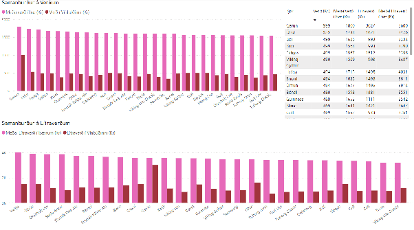

Versti bjórinn í samanburði, með tilliti til verðs á lítra, var Tuborg Grön, sem kostaði 4,67 sinnum meira á lítra í miðbænum miðað við Vínbúðina. Þetta undirstrikar mikilvægi þess að skoða bæði verð á lítra og stærð glasa þegar það á að meta verðmun á milli staða.

## **Bjórar - Fjöldi/Verð**

Þessi blaðsíða mælaborðsins sýnir samanburð á fjölda bjóra og meðalverði á milli bara í Reykjavík. Barir með mesta úrvalið eru “Den Danske Kro,” “The English Pub,” og “The Irishman Pub,” sem hver hefur 10 mismunandi bjóra á boðstólum, en “Kaffibarinn” fylgir með 9 tegundir og “Lebowski Bar” með 8. Barir með minna úrval, eins og “BrewDog Reykjavik,” eru með aðeins 1-2 bjóra í boði. Það er samt misvísandi upplýsingar að “BrewDog Reykjavik” og “Session Craft Bar” séu aðeins með einn bjór á dælu því að í rauninni eru þeir með mun fleiri. Það var samt ekki tekið með í gagnasafnið þar sem ekkert verð var á þeim þar sem þeir eru árstíðabundnir og síbreytilegir.

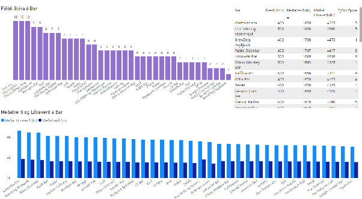

Þegar kemur að meðalverði á lítra eru barir eins og “Kokteilbarinn,” “BrewDog Reykjavik,” og “Pablo Discobar” með hæsta verð, þar sem “Kokteilbarinn” er dýrastur með 4.625 krónur á lítra. Ódýrari barir, eins og “Den Danske Kro” og “The Irishman Pub,” bjóða upp á lægri meðalverð, barinn með lægsta meðalverðið fyrir lítrann er “Gaukurinn”, 3080kr.

## **Happy Hour**

Af 36 stöðum sem skoðaðir voru, buðu 28 staðir upp á Happy Hour. Tímasetningar Happy Hour voru almennt á milli kl. 16:00 og 19:00, með langflesta staði (9) á þessu tímabili. Lengsta Happy Hour-ið fannst á Dillon Whiskey Bar og The Irishman Pub, þar sem það hófst kl. 12:00 og endaði kl. 19:00.

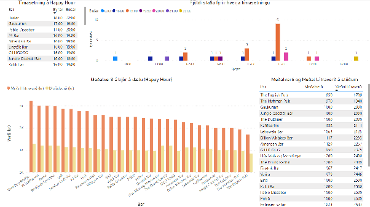

## **Lukkuhjól**

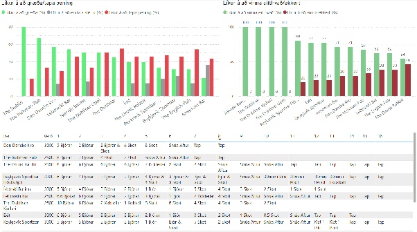

Tapreitir voru algengir á flestum lukkuhjólum. Til dæmis hafði The Drunk Rabbit hæsta hlutfallið af þeim, þar voru 46% reita tap. Þessar niðurstöður sýna mikilvægi þess að skoða líkur og verð á hjólunum áður en tekin er ákvörðun um hvort það eigi að snúa hjólinu eða ekki.

## **Bjórkort**

Gögnin af stöðunum leiddi í ljós mikinn breytileika í verðlagningu bjóra á dælu, allt frá hagkvæmum til mun dýrari drykkja. Meðalverð bjórs á dælu í miðbænum var á bilinu 1.300 kr. til 1.990 kr. fyrir 400-500 ml. Ódýrasti drykkurinn fannst á SKOR (Gull Lite, 400 ml, 1.300 kr.), en dýrasti bjórinn var Úlfrún á Kokteilbarnum (400 ml, 1.990 kr.).

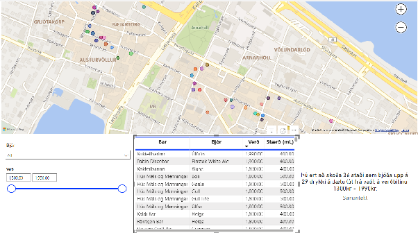

Greiningin sýndi einnig að flestir staðir í miðbænum buðu upp á 400 ml bjórglös, en stærri glös (500 ml) voru sjaldgæfari. Í heildina voru 26 staðir með Gull Lite á dælu, sem gerir það að algengasta bjórnum. Á hinn bóginn voru bjórar eins og Gárún, Ölvisholt Lite, Thule og Víking Lite Classic aðeins í boði á einum stað hver.

## **Heildarniðurstöður og mynstur**

Verkefnið leiddi í ljós ákveðin mynstur og ályktanir sem varpa ljósi á verðlagningu og aðgengi bjóra í miðbæ Reykjavíkur:

- Staðir sem buðu upp á fjölbreytt úrval bjóra, eins og Den danske Kro og The English Pub, höfðu almennt meðalverð sem var samkeppnishæft miðað við staði með minna úrval. Úrvalið á þessum stöðum náði yfir sértækari bjórtegundir, sem gerði það að verkum að fleiri viðskiptavinir geta fundið eitthvað við sitt hæfi. Þetta úrval leyfði einnig sveigjanlegt verðbil, sem gerði þá samkeppnishæfa miðað við staði sem bjóða upp á færri valkosti.
- Happy Hour var helsta leiðin til að fá bjór á hagstæðara verði, en tímalengd og verð breyttust verulega milli staða. Langflestir staðir buðu Happy Hour á milli kl. 16:00 og 19:00, en mismunandi uppsetning varðandi afslátt og tímalengd skapaði fjölbreyttar upplifanir. Sumir staðir drógu úr verði með lengri tímabilum, á meðan aðrir lögðu áherslu á hámarksafslátt á styttri tíma.
- Vínbúðin er mun hagkvæmari kostur í samanburði við miðbæinn, en hlutfallið á milli verðs á lítra fer eftir stærðum glasa í miðbænum. Minni glös, eins og 400 ml, sýndu stærri verðmun miðað við Vínbúðina, á meðan stærri glös, eins og 500 ml, gerðu lítraverð bjórs í miðbænum samkeppnishæfara. Þetta sýnir mikilvægi þess að taka tillit til bæði stærðar og verðs í samanburðinum.

# Umræða

Niðurstöður verkefnisins sýna fjölbreytni og flækjustig í verðlagningu og aðgengi bjóra í miðbæ Reykjavíkur og samanburð við verð í Vínbúðinni. Umræðan í þessum kafla leggur áherslu á greiningu á niðurstöðum í samhengi við rannsóknarspurningar verkefnisins, ásamt því að skoða hvernig niðurstöður tengjast upphaflegum markmiðum og mögulegum lærdómum fyrir frekari rannsóknir.

## **Fjölbreytni og verðlagning bjóra í miðbæ Reykjavíkur**

Eitt helsta markmið verkefnisins var að greina hvernig verð á bjór í miðbænum breytist eftir staðsetningu, tegundum og stærðum glasa. Greiningin sýndi að staðir með fjölbreytt úrval, eins og Den danske Kro og The English Pub, höfðu samkeppnishæft meðalverð samanborið við minni staði með takmarkað úrval. Þetta undirstrikar mikilvægi fjölbreytni fyrir aðdráttarafl staða, þar sem neytendur virðast vera tilbúnir að borga meira fyrir fjölbreyttari valkosti.

Á hinn bóginn sýndu niðurstöðurnar einnig að vinsælasti bjórinn, Gull Lite, var í boði á flestum stöðum, sem bendir til þess að staðir reyni að höfða til breiðs markhóps með því að hafa vinsælar tegundir aðgengilegar. Þetta veldur þó spurningu um það hvort minni fjölbreytni sé í raun nægileg fyrir staði sem vilja draga úr kostnaði en samt höfða til neytenda.

## **Happy Hour**

Happy Hour reyndist vera lykilþáttur í verðlagningu staða í miðbænum, þar sem 28 af 36 stöðum buðu upp á þessi tilboð. Lengd og tímasetningar Happy Hour breyttust þó verulega milli staða. Sumir, eins og Dillon Whiskey Bar og The Irishman Pub, buðu upp á löng tímabil frá kl. 12:00 til 19:00, sem gæti skýrt hvers vegna þeir laða að fjölbreyttari hópa viðskiptavina. Aðrir staðir lögðu áherslu á styttri tímabil með meiri afslætti, sem er hannað til að hámarka viðskiptavini á ákveðnum tímum.

Þessar niðurstöður vekja spurningar um það hversu áhrifarík mismunandi aðferðir eru við að nýta Happy Hour til að hámarka hagnað. Er betra að hafa lengri tímabil með minni afslætti eða styttri tímabil með meiri afslætti? Frekari rannsóknir gætu greint áhrif þessara nálgana á tekjur og viðskiptavinaflæði.

## **Lukkuhjól og vinningslíkur**

Greining á lukkuhjólum sýndi mikinn breytileika í vinningslíkum milli staða, þar sem hæsta vinningshlutfallið var hjá The Dubliner (80%) og það lægsta hjá The American Bar (21%). Þessar niðurstöður vekja athygli á því hvernig staðir nýta lukkuhjól sem skemmtunartæki, þar sem margir viðskiptavinir gætu verið meira áhugasamir um spennuna við að spila frekar en raunverulegan hagnað.

Á hinn bóginn sýna gögnin einnig að hátt hlutfall tapreita gæti haft neikvæð áhrif á upplifun viðskiptavina, sérstaklega ef líkur á vinningi eru lágar og verð hjólanna hátt. Þetta vekur spurningar um jafnvægið milli þess að bjóða skemmtilega upplifun og tryggja sanngjarnan vinning fyrir viðskiptavini.

## **Tengsl niðurstaðna við námsefni**

Verkefnið nýtti sér helstu aðferðir námskeiðsins, eins og REGEX, SQL og Power BI, til að greina gögn og setja niðurstöður fram á sjónrænan hátt. Þetta sýnir mikilvægi þess að beita fjölbreyttum tækjum og tækni við úrvinnslu gagna. Niðurstöðurnar sýna einnig hvernig samspil tækni og innsæis getur veitt dýpri skilning á flóknum viðfangsefnum, eins og verðlagningu og upplifun viðskiptavina.

## **Áskoranir og mögulegur lærdómur**

Einn helsti lærdómur verkefnisins er mikilvægi þess að samræma gögn frá ólíkum uppsprettum gagna. Að samræma nöfn bjóra milli miðbæjarins og Vínbúðarinnar krafðist handvirkrar vinnu, sem hefði verið hægt að einfalda með stærra og stöðluðu gagnasafni. Frekari rannsóknir gætu einblínt á að þróa sjálfvirkari leiðir til að staðla gögn.

Auk þess sýndu gögnin að verðlagning og tilboð breyttust verulega milli staða. Þetta bendir til þess að fleiri rannsóknir á hegðun neytenda gætu veitt innsýn í hvernig þessir þættir hafa áhrif á val þeirra. Slík innsýn gæti nýst veitingastöðum til að bæta verðlagningu sína og þjónustu.

# Samantekt

Samanburður á lítraverði miðbæjarins og Vínbúðarinnar sýndi mikilvægi stærðar glasa fyrir hagkvæmni. Þrátt fyrir hærra verð í miðbænum getur stærð glasa, eins og 500 ml, bætt samkeppnisstöðu staða á lítraverði. Þetta vekur spurningar um hvort staðir gætu aukið samkeppnishæfni sína með því að leggja áherslu á stærri glös til viðbótar við hefðbundin 400 ml glös. Lukkuhjól staðanna sýndu einnig áhugaverðan breytileika í upplifun og viðhorfum viðskiptavina. Staðir með hátt vinningshlutfall, eins og The Dubliner, virðast bæta upplifun viðskiptavina með sanngjörnum vinningum. Hins vegar gæti hátt hlutfall tapreita á sumum stöðum, eins og The American Bar, dregið úr ánægju og jafnvel letja viðskiptavini frá þátttöku.

Verkefnið undirstrikaði mikilvægi í ákvörðun verðlagningu og þjónustu. Sveigjanleiki í Happy Hour, stærð glasa og jafnvægi í upplifun, eins og í lukkuhjólum, geta haft áhrif á samkeppnishæfni staða. Auk þess var verkefnið mikilvægt til að sýna hvernig greining gagna, með tækni á borð við REGEX, SQL og Power BI, getur veitt dýpri innsýn í samanburð staða og væntingar viðskiptavina til mismunandi tilboða þeirra. Fyrir framtíðarrannsóknir væri áhugavert að skoða fleiri þætti sem hafa áhrif á verðlagningu, eins og áhrif árstíðar, staðsetningar innan borgarinnar eða vinsældir einstakra staða. Að auki gæti verið gagnlegt að kanna sambandið milli þjónustustigs og verðlagningar til að skilja betur hvernig neytendur meta virði í miðbæ Reykjavíkur.

# Heimildaskrá

**Spurningarlisti í persónu**. (okt. 2024). Gagnaöflun framkvæmd á eftirfarandi stöðum í miðbæ Reykjavíkur: Hax, Kokteilbarinn, The Irishman Pub, Rvk Sportbar, Brewdog, Dillon Whiskey Bar, 22 Bar, Veður, Kaldi Bar, Lebowski, Bastard Brew & Food, Kaffibarinn, Einstök, Bingo Drinkery, Session Craft Bar, Prikið, Röntgen, Sky Bar, Íslenski Barinn, Petersen, Loft, Icelandic Craft Bar, The Downtown Bar, Lemmy, Drykk Bar, Skuggi, Jungle, Lúx, English, American, Drunk Rabbit, Exit, Pablo Discobar, Frederiksen Ale House, Dubliner, Paloma, Radar og Gaukurinn.

**Vínbúðin.** (okt.2024). Upplýsingar um verð og stærðir bjóra. Sótt af https://www.vinbudin.is.